# Tarea 4 Genomica funcional: REDES

### Red PPI

```r
library(igraphdata)

data("yeast")

class(yeast)
```

```
## [1] "igraph"
```

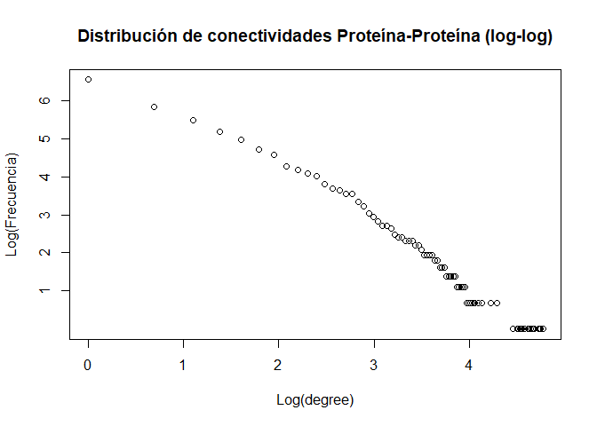

```r
## Distribucion de conexiones

yeast_p <- Red_propiedades(yeast)

# Primero en el eje de las x asignamos los valores de degree que se presentan en la red.
x <- as.numeric(names((table(yeast_p$Degree))))

# Y despues en el eje de las y asignamos en orden las frecuencias obtenidas para cada valor de degree
y <- sort((table(yeast_p$Degree)), decreasing = TRUE)

# log log, vamos a graficar los ejes antes calculados con su respectivo logaritmo en cada eje.

plot(log(x), log(y), xlab = "Log(degree)", ylab = "Log(Frecuencia)", main = "Distribución de conectividades Proteína-Proteína (log-log)")
```

10 proteinas mas conectadas

```r
sort(degree(yeast), decreasing = TRUE)[c(1:10)]
```

```
## YPR110C YPL131W YNL178W YIL021W YOL127W YJL063C YBR283C YLR378C YMR260C YBR251W
##     118     115     114     113     113     108     108     108     107     106
```

Diamentro

```r
yeast_p$Diametro
```

```
## [1] 15
```

Promedio de distancias

```r
mean(yeast_p$Matriz_distancia)
```

```
## [1] Inf
```

```r
is.connected(yeast)
```

```
## [1] FALSE
```

```r
# Esto significa que dentro del grafo yeast hay subgrafos conectados entre si por edges pero que no tienen conexion entre ellos, por lo que, si queremos hacer el calculo de matriz de distancias entre nodos tenemos que hacerlo unicamente dentro de los subgrafos, ya que si no obtendremos infinito como respuesta ya que no es posible la conexion entre nodos de diferentes subgrafos.

components <- components(yeast) # Aqui estamos extrayendo los componentes del grafo principal, de tal forma que estos componentes estan compuestos por los nodos conectados entre si, osea los subgrafos.

media <- c()

# Vamos a realizar un ciclo for para calcular la media de distancias en cada subgrafo que tenga mas de 1 nodo perteneciente.

for (i in 1:(sort(components$membership, decreasing = TRUE)[1])) { # Aqui estamos haciendo que el ciclo for itere hasta el componente mas alto en el vector con la mayor cantidad de nodos en el calculo de componentes, es decir, encontramos aquel vector de componentes con la mayor cantidad de nodos y de ahi extraemos el componente mas grande que contiene para que se itere hasta el, de tal forma que pase por todos los componentes creados.
  nodos <- which(components$membership == i) # Aqui estamos obteniendo los nodos que pertenecen al componente i.
  subgrafo <- induced.subgraph(yeast, nodos) # Aqui creamos un subgrafo que contiene solo los nodos seleccionados por el componente.
  if (gorder(subgrafo) > 1) { ## Aqui estamos condicionando el la iteracion del ciclo para que solo continue si el subgrafo generado tiene mas de 1 nodo.
    mdist <- distances(subgrafo) # calculamos la matriz de distancias del subgrafo.
    media <- c(media, mean(mdist[mdist < Inf])) # calculamos la media omitiendo aquellos valores que podriamos tener un valor de infinito.
  }
}

media
```

```
##  [1] 5.0938245 0.6666667 1.4400000 1.6000000 1.7959184 1.7222222 1.1250000
##  [8] 0.8888889 1.0400000 0.5000000 1.5510204 0.5000000 0.5000000 1.7959184
## [15] 0.8888889 0.5000000 0.5000000 1.1250000 0.5000000 0.5000000 0.5000000
## [22] 0.5000000 0.5000000 0.5000000 0.5000000 0.5000000 0.5000000 0.5000000
## [29] 0.5000000 0.5000000 0.5000000 1.1250000 0.5000000 0.5000000 0.5000000
## [36] 0.5000000 0.5000000 1.0400000 0.5000000 0.5000000 0.8888889 0.5000000
## [43] 0.5000000 0.8888889 0.5000000 0.5000000 1.4400000 0.6666667 0.8888889
## [50] 0.5000000 0.5000000 0.5000000 0.5000000 0.8888889 0.8888889 0.5000000
## [57] 0.5000000 0.5000000 0.5000000 0.5000000 0.5000000 0.5000000 0.5000000
## [64] 0.5000000 0.5000000 0.5000000 0.5000000 0.5000000 0.5000000 0.5000000
## [71] 0.5000000 0.8888889 1.2800000 0.8888889 0.8888889 1.1250000 0.5000000
## [78] 0.5000000 0.5000000 0.5000000 0.5000000 0.8888889 0.5000000 0.5000000
## [85] 1.1250000 0.5000000 0.5000000 0.5000000 0.5000000 0.5000000 0.5000000
## [92] 0.5000000
```

```r
## Estas son las medias de las distancias en aquellos subgrafos generados con mas de 1 nodo que los compone.
```

Funcion para elimiar nodos

```r
Robustness <- function(red, numero_nodos){
  inter <- as.character(c(V(red)))
  res <- list(
    Nodo_removido = c(rep(0, (numero_nodos + 1))),
    Diametro = c(diameter(red), rep(0, numero_nodos)),
    distancia_media = c(
      mean(media), ## Voy a utilizar la media de las medias de los subgrafos con mas de 1 nodo para evitar hacer listas de listas
      rep(0, numero_nodos)
    )
  )
  for (i in 1:numero_nodos){
    x <- sample(inter, 1)
    inter <- inter[inter != x]
    red <- delete.vertices(red, V(red)$x)
    components <- components(red)
    media2 <- c()
    for (j in unique(components$membership)){
      nodos <- which(components$membership == j)
      subgrafo <- induced.subgraph(red, nodos)
      if (gorder(subgrafo) > 1) {
        mdist <- distances(subgrafo)
        media2 <- c(media2, mean(mdist[mdist < Inf]))
      }
    }
    res[[1]][(i + 1)] <- x
    res[[2]][(i + 1)] <- diameter(red)
    res[[3]][(i + 1)] <- mean(media2)
  }
  return(res)
}

Robustness(yeast, 100)

write.csv(Robustness(yeast, 100), "../Data/distancias.eliminandonodosppi.csv")
```

```r
# Debido a que es un ciclo muy pesado el resultado esta precargado

distanciasppi <- read.csv("../Data/distancias.eliminandonodosppi.csv")
distanciasppi
```

```
##       X Nodo_removido Diametro distancia_media
## 1     1             0       15        0.739511
## 2     2           829       15        0.739511
## 3     3           893       15        0.739511
## 4     4          2307       15        0.739511
## 5     5          1065       15        0.739511
## 6     6          2330       15        0.739511
## 7     7          1063       15        0.739511
## 8     8          1559       15        0.739511
## 9     9          1294       15        0.739511
## 10   10           638       15        0.739511
## 11   11          2365       15        0.739511
## 12   12          2519       15        0.739511
## 13   13           924       15        0.739511
## 14   14          1159       15        0.739511
```

[output cut: 87 more lines]

Funcion para eliminar proteinas mas conectadas y calcular distancias cada que se elimina una

```r
No_prote_conectada <- function(red, no_protes){
  d <- degree(red)
  names(d) <- V(red)
  inter <- as.character(names(sort(d, decreasing = TRUE)[1:no_protes]))
  numero_nodos <- length(inter)
  res <- data.frame(
    Nodo_removido = c(rep(0, (numero_nodos + 1))),
    Degree_Nodo_removido = c(rep(0, (numero_nodos + 1))),
    Diametro = c(diameter(red), rep(0, numero_nodos)),
    distancia_media = c(
      mean(media),
      rep(0, numero_nodos)
    )
  )
  for (i in 1:numero_nodos){
    x <- inter[1]
    inter <- inter[-1]
    red2 <- delete.vertices(red, V(red)$x)
    components <- components(red2)
    media2 <- c()
    for (j in unique(components$membership)){
      nodos <- which(components$membership == j)
      subgrafo <- induced.subgraph(red2, nodos)
      if (gorder(subgrafo) > 1) {
        mdist <- distances(subgrafo)
        media2 <- c(media2, mean(mdist[mdist < Inf]))
      }
    }
    res[[1]][(i + 1)] <- x
    res[[2]][(i + 1)] <- (sort(d, decreasing = TRUE)[1:no_protes])[i]
    res[[3]][(i + 1)] <- diameter(red)
    res[[4]][(i + 1)] <- mean(media2)
  }
  return(res)
}

No_prote_conectada(yeast, 12)
```

```
##    Nodo_removido Degree_Nodo_removido Diametro distancia_media
## 1              0                    0       15        0.739511
## 2            286                  118       15        0.739511
## 3            698                  115       15        0.739511
## 4            713                  114       15        0.739511
## 5             70                  113       15        0.739511
## 6            123                  113       15        0.739511
## 7            139                  108       15        0.739511
## 8            722                  108       15        0.739511
## 9            723                  108       15        0.739511
## 10           842                  107       15        0.739511
## 11            65                  106       15        0.739511
## 12           108                  106       15        0.739511
## 13           109                  106       15        0.739511
```

```r
# Con el metodo que use no se observa diferencias en la distancia o en el diametro de la red al quitar los nodos con el mayor degree, mi teoria es que mi tecnica para calcular la distancia esta mal ejecutada.
```

Calcula el proemdio del coeficiente de clusterización. ¿Hay proteínas que tengan un coeficiente de clusterización de 1? Eso qué significa

```r
# Para calcular el coeficiente de clusterizacion tenemos que usar la funcion transitivity, luego eliminar los valores NA y calcular la media
tra <- transitivity(yeast, type = "local")
tra <- tra[which(tra <= 1 & tra >= 0)]
mean(tra)
```

```
## [1] 0.3870165
```

```r
length(which(tra == 1))
```

```
## [1] 216
```

Como podemos ver la media es de 0.38 y la cantidad de proteinas con una transitividad de 1 son 216, esto significa que las proteinas con las que interactua la proteina A tienen el maximo de interacciones entre ellas.

### Redes Biologicas

Extraer del network repository la red de la corteza cerebral del raton

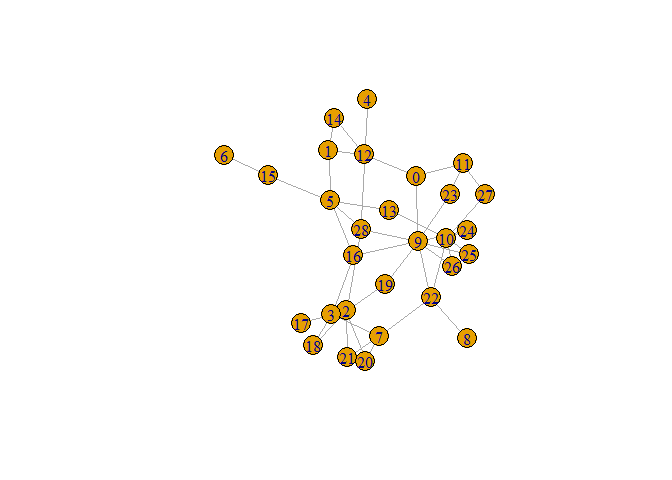

```r
graph_data_dir <- 'graph_data'
network_repository_dir <- file.path(graph_data_dir, "network_repository")
network_repository_zipdir <- file.path(network_repository_dir, "zips")
url_i <- "https://nrvis.com/download/data/bn/bn-mouse_visual-cortex_1.zip"
destfile_i <- file.path(network_repository_zipdir, basename(url_i))
download.file(url_i, destfile = destfile_i, quiet = TRUE)
unzip(destfile_i, exdir = paste0(network_repository_zipdir))
g_file <- grep("\\.edges$", list.files(network_repository_dir, full.names = TRUE, recursive = TRUE), value = TRUE)[1]
df_i <- read.delim(g_file, sep = " ", header = FALSE)
df_i[] <- lapply(df_i, as.character)
df_i <- df_i[!duplicated(df_i), ]
mouse <- graph_from_data_frame(df_i, directed = FALSE)

plot(mouse)
```

El codigo para extraer esta red biologica se obtuvo del [github de robertoshea](https://github.com/robertoshea/graph_isomorphism/blob/main/main)

GeneraR la gráfica con todos los layouts disponibles

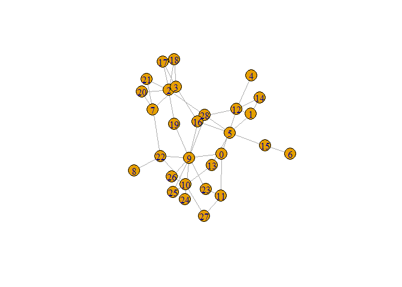

```r
coords <- layout_(mouse, as_star())
coords2 <- layout_(mouse, as_tree())

plot(mouse)
```

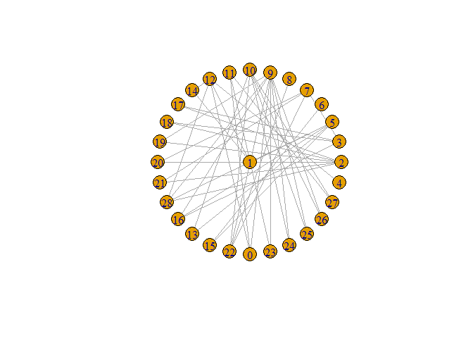

```r
plot(mouse, layout = coords)
```

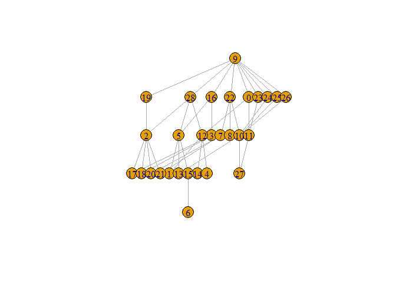

```r
plot(mouse, layout = coords2)
```

Graficar la red con al menos tres medidas de centralidad.

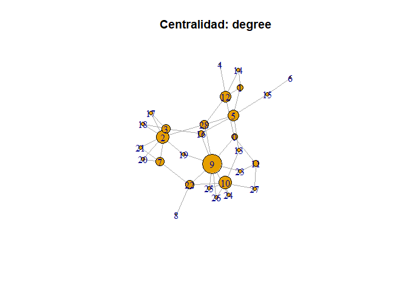

```r
plot(mouse, layout = layout_nicely, vertex.size = degree(mouse)*3,
     main = "Centralidad: degree")
```

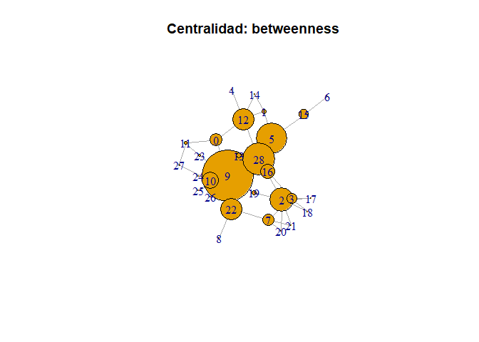

```r
plot(mouse, layout = layout_nicely, vertex.size = betweenness(mouse)*0.5,
     main = "Centralidad: betweenness")
```